# Seurat and MOFA+ interoperability

Tutorial describing how to create and train a MOFA+ model starting from a Seurat object or a list of matrices. In otder to be familiar to Seurat users, for the data preprocessing we follow Seurat’s guided clustering tutorial.

Danila Bredikhin https://gtca.github.io/ (EMBL)https://www.embl.de/research/units/genome_biology/stegle/members/  
2019-11-07

```r
library(Seurat)
library(MOFA2)
library(Matrix)
```

# Prepare the data

## Seurat

We follow [Seurat’s guided clustering tutorial](https://satijalab.org/seurat/v3.0/pbmc3k_tutorial.html) for PBMC 3k data preprocessing, which might be already familiar for Seurat users.

```r
# Download and untar PBMC dataset (7.3 Mb)
#system("wget -P data/pbmc3k/ 'https://s3-us-west-2.amazonaws.com/10x.files/samples/cell/pbmc3k/pbmc3k_filtered_gene_bc_matrices.tar.gz'")
#system("tar -C data/pbmc3k/ -zxvf 'data/pbmc3k/pbmc3k_filtered_gene_bc_matrices.tar.gz'")

# Will create a 55.6 Mb object
pbmc.data <- Read10X(data.dir = "../data/pbmc3k/filtered_gene_bc_matrices/hg19/")

# Will create a 28.5 Mb object
pbmc <- CreateSeuratObject(counts = pbmc.data, project = "pbmc3k", min.cells = 10, min.features = 200)
pbmc
```

```
An object of class Seurat
11139 features across 2700 samples within 1 assay
Active assay: RNA (11139 features)
```

Firstly, we go through the pre-processing steps from the aforementioned tutorial.

```r
# QC
pbmc[["percent.mt"]] <- PercentageFeatureSet(pbmc, pattern = "^MT-")
pbmc <- subset(pbmc, subset = nFeature_RNA > 200 & nFeature_RNA < 2500 & percent.mt < 5)

# Normalising the data
pbmc <- NormalizeData(pbmc, normalization.method = "LogNormalize", scale.factor = 10000)

# Feature selection
pbmc <- FindVariableFeatures(pbmc, selection.method = "vst", nfeatures = 1000)

# Scaling the data
pbmc <- ScaleData(pbmc)

# Dimensionalisty reduction: PCA and UMAP
pbmc <- RunPCA(pbmc, features = VariableFeatures(object = pbmc))
pbmc <- RunUMAP(pbmc, dims = 1:10)

# Defining clusters of cells based on their gene expression profiles
pbmc <- FindNeighbors(pbmc, dims = 1:10)
pbmc <- FindClusters(pbmc, resolution = 0.5)
```

```
Modularity Optimizer version 1.3.0 by Ludo Waltman and Nees Jan van Eck

Number of nodes: 2637
Number of edges: 97981

Running Louvain algorithm...
Maximum modularity in 10 random starts: 0.8671
Number of communities: 8
Elapsed time: 0 seconds
```

Check how the data looks like on a UMAP plot:

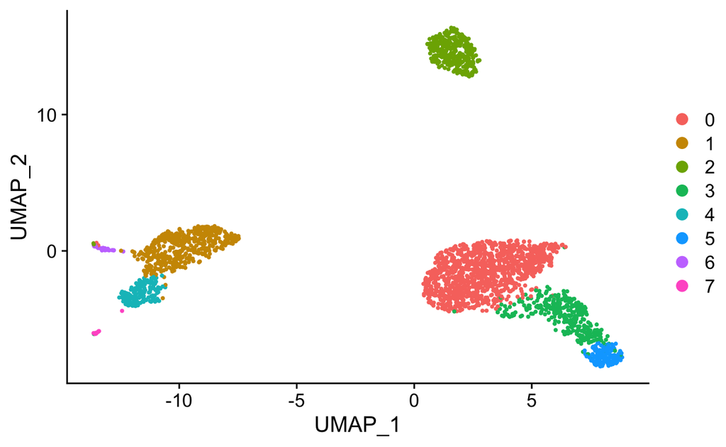

```r
DimPlot(pbmc, reduction = "umap")
```

# Train the model

Having the Seurat object in place, we then provide it to the `create_mofa()` function that will create a MOFA+ model using the desired slots of the Seurat object.

```r
factor_model <- create_mofa(pbmc,
                            # Groups can be provided at this step
                            # as a respective metadata column:
                            # groups = pbmc@meta.data$data_batch,

                            # Features to use for the model can be supplied via `features` argument:
                            features = VariableFeatures(pbmc),

                            # Slot to select from each assay
                            slot = "data")
factor_model
```

```
Untrained MOFA model with the following characteristics:
 Number of views: 1
 Views names: rna
 Number of features (per view): 1000
 Number of groups: 1
 Groups names: group1
 Number of samples (per group): 2637
```

In order to have a control over the model parameters and training procedure, we have to provide the fill the respective model slots. Below, we run `prepare_mofa()` that would use all the default options, and then manually adjust a few paramters.

```r
# Use all the default options to prepare the model for training
factor_model <- prepare_mofa(factor_model)

# Set the number of factors to learn to 10.
# Note that you might want to consider setting it
# to a larger number for your dataset
factor_model@model_options$num_factors <- 10

# If you wish, you can turn the verbose output during training on
# so that you're able to monitor the training procedure,
# and there are two knobs to adjust for that
# factor_model@training_options$verbose <- TRUE
# factor_model@training_options$quite <- FALSE

# Set convergense mode to "fast",
# which means we could be able to finish training earlier
# disregarding small improvements in convergence
# that we might gain in medium or slow modes
factor_model@training_options$convergence_mode <- "fast"
factor_model@training_options$maxiter <- 500
```

Run the training. For that, the data is passed to the core of MOFA+ written in Python:

```r
factor_model <- run_mofa(factor_model)
```

Calling the factor model object will give an overview of the model:

```r
factor_model
```

```
Trained MOFA with the following characteristics:
 Number of views: 1
 Views names: rna
 Number of features (per view): 1000
 Number of groups: 1
 Groups names: group1
 Number of samples (per group): 2637
 Number of factors: 10
```

## Other formats

The model constructor function `create_mofa()` accepts the data in a multitude of formats including a Seurat object (demonstrated above) and a list of matrices (`matrix`, `dgCMatrix`, or `dgTMatrix`) in R as well as AnnData or loom objects in Python. The information on the latter formats can be found in the respective notebooks, and here’s how to use a list of matrices to create the model:

```r
pbmc_counts <- readMM("../data/pbmc3k/filtered_gene_bc_matrices/hg19/matrix.mtx")
# Do the basic preprocessing with base R
pbmc_counts <- pbmc_counts / colSums(pbmc_counts) * 1e4  # genes are in rows
# Get top expressed genes
pbmc_counts <- pbmc_counts[rowSums(pbmc_counts) > 1e3, colSums(pbmc_counts) < 3*1e4]
pbmc_counts <- as(log(pbmc_counts+1), "dgTMatrix")

fm_mtx <- create_mofa(list("rna" = pbmc_counts))
fm_mtx
```

```
Untrained MOFA model with the following characteristics:
 Number of views: 1
 Views names: rna
 Number of features (per view): 3157
 Number of groups: 1
 Groups names: group1
 Number of samples (per group): 2672
```

Please note above that `create_mofa()` accepts a list of matrices with each element corresponding to a view.

# Explore the model

A good place to start exploring the trained model is to see how much variance each factor explains in every group:

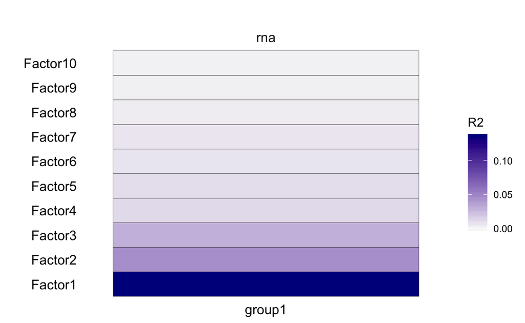

```r
plot_variance_explained(factor_model, x = "group")
```

We could also add seurat clusters information and see how factor values are distributed for every group of cells:

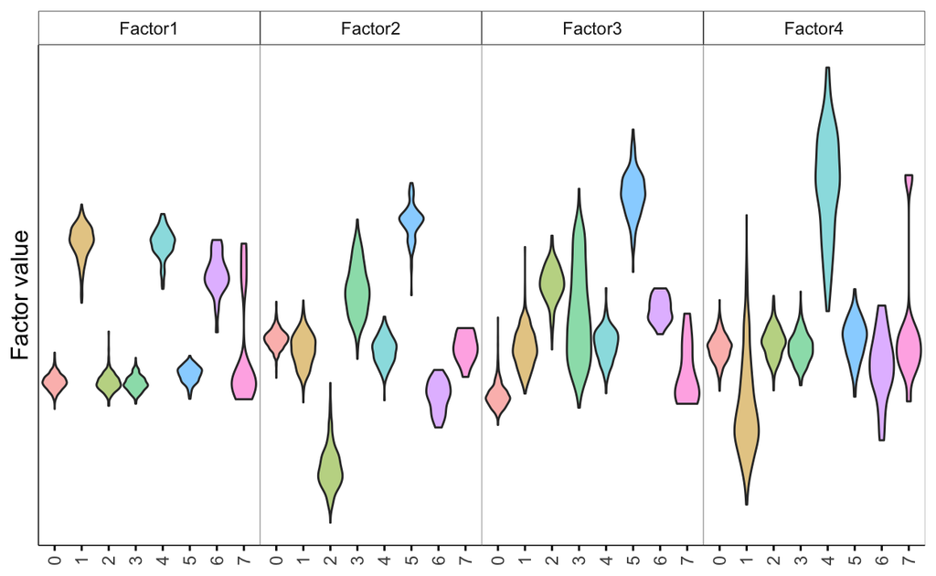

```r
sample_order <- match(samples_metadata(factor_model)$sample, rownames(pbmc@meta.data))
samples_metadata(factor_model)[,"seurat_clusters"] <- pbmc@meta.data[sample_order,"seurat_clusters"]

plot_factor(factor_model, factors = 1:4, add_dots = FALSE, add_violin = TRUE,
            group_by = 'seurat_clusters', color_by = 'seurat_clusters')
```

A factor is defined by a set of weights (loadings) on features (genes in this case), and that’s what can be used to interpret factors:

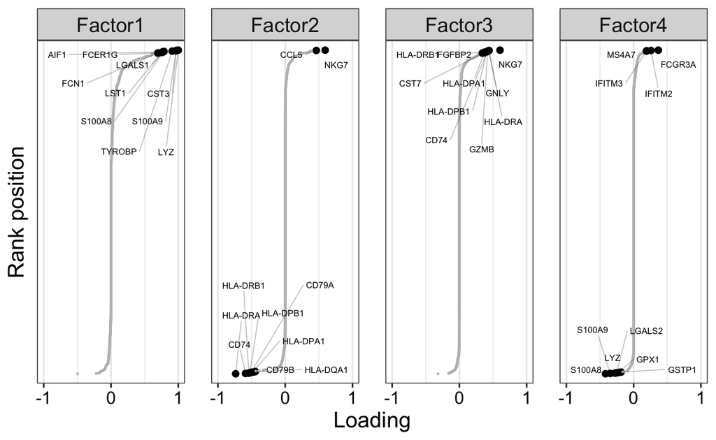

```r
plot_weights(factor_model, factors = 1:4, text_size = 2)
```

We can also use methods like UMAP for non-linear dimensionality reduction and overlay the factors values:

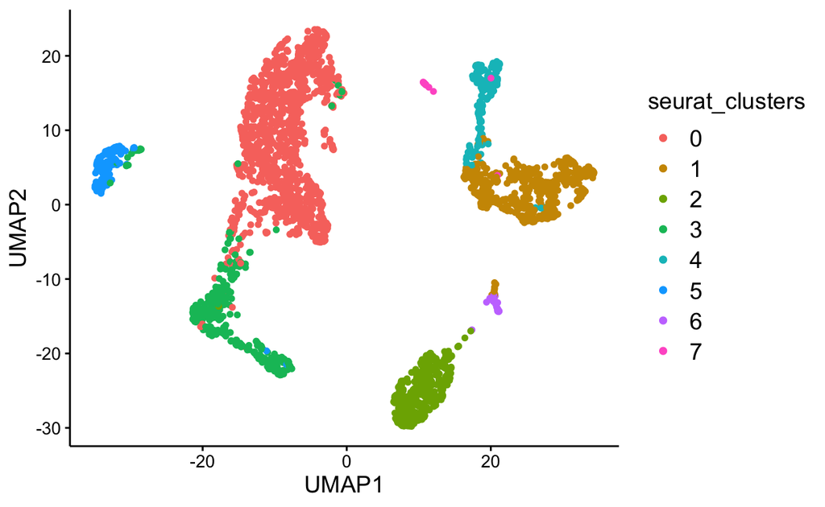

```r
set.seed(100)
factor_model <- run_umap(factor_model, spread = 5)
plot_dimred(factor_model, method = "UMAP", color_by = "seurat_clusters")
```

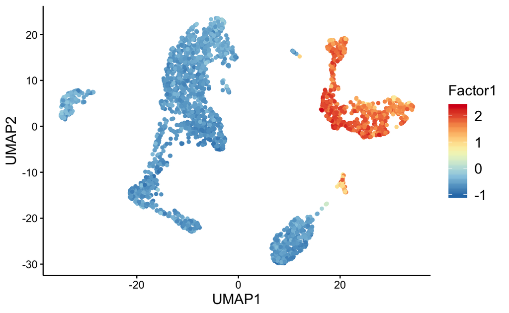

```r
plot_dimred(factor_model, method = "UMAP", color_by = "Factor1")
```

If we want to operate on a Seurat object further on, we can add respective factor values as metadata:

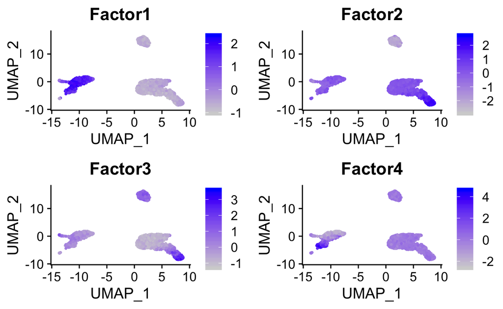

```r
factor_values <- do.call(rbind, get_factors(factor_model, factors = 1:4))
sample_order <- match(rownames(pbmc@meta.data), rownames(factor_values))
pbmc@meta.data <- cbind(pbmc@meta.data, factor_values[sample_order,])

FeaturePlot(pbmc, reduction = "umap", features = paste0("Factor", 1:4))
```

Please see further vignettes for model investigation and factors interpretation.